# White wine quality exploration by Lee Saldanha

# Univariate Analysis

### What is the structure of your dataset?

The white wines dataset has 4,898 records and 13 columns/variables originally. All the feature variables (thus excluding quality and ID/X) have continuous values.

```
## 'data.frame':    4898 obs. of  14 variables:
##  $ X                   : int  1 2 3 4 5 6 7 8 9 10 ...
##  $ fixed.acidity       : num  7 6.3 8.1 7.2 7.2 8.1 6.2 7 6.3 8.1 ...
##  $ volatile.acidity    : num  0.27 0.3 0.28 0.23 0.23 0.28 0.32 0.27 0.3 0.22 ...
##  $ citric.acid         : num  0.36 0.34 0.4 0.32 0.32 0.4 0.16 0.36 0.34 0.43 ...
##  $ residual.sugar      : num  20.7 1.6 6.9 8.5 8.5 6.9 7 20.7 1.6 1.5 ...
##  $ chlorides           : num  0.045 0.049 0.05 0.058 0.058 0.05 0.045 0.045 0.049 0.044 ...
##  $ free.sulfur.dioxide : num  45 14 30 47 47 30 30 45 14 28 ...
##  $ total.sulfur.dioxide: num  170 132 97 186 186 97 136 170 132 129 ...
##  $ density             : num  1.001 0.994 0.995 0.996 0.996 ...
##  $ pH                  : num  3 3.3 3.26 3.19 3.19 3.26 3.18 3 3.3 3.22 ...
##  $ sulphates           : num  0.45 0.49 0.44 0.4 0.4 0.44 0.47 0.45 0.49 0.45 ...
##  $ alcohol             : num  8.8 9.5 10.1 9.9 9.9 10.1 9.6 8.8 9.5 11 ...
##  $ quality             : int  6 6 6 6 6 6 6 6 6 6 ...
##  $ bound.sulfur.dioxide: num  125 118 67 139 139 67 106 125 118 101 ...
```

```
##        X        fixed.acidity    volatile.acidity  citric.acid
##  Min.   :   1   Min.   : 3.800   Min.   :0.0800   Min.   :0.0000
##  1st Qu.:1225   1st Qu.: 6.300   1st Qu.:0.2100   1st Qu.:0.2700
##  Median :2450   Median : 6.800   Median :0.2600   Median :0.3200
##  Mean   :2450   Mean   : 6.855   Mean   :0.2782   Mean   :0.3342
##  3rd Qu.:3674   3rd Qu.: 7.300   3rd Qu.:0.3200   3rd Qu.:0.3900
##  Max.   :4898   Max.   :14.200   Max.   :1.1000   Max.   :1.6600
##  residual.sugar     chlorides       free.sulfur.dioxide
##  Min.   : 0.600   Min.   :0.00900   Min.   :  2.00
##  1st Qu.: 1.700   1st Qu.:0.03600   1st Qu.: 23.00
##  Median : 5.200   Median :0.04300   Median : 34.00
##  Mean   : 6.391   Mean   :0.04577   Mean   : 35.31
##  3rd Qu.: 9.900   3rd Qu.:0.05000   3rd Qu.: 46.00
##  Max.   :65.800   Max.   :0.34600   Max.   :289.00
##  total.sulfur.dioxide    density             pH          sulphates
##  Min.   :  9.0        Min.   :0.9871   Min.   :2.720   Min.   :0.2200
##  1st Qu.:108.0        1st Qu.:0.9917   1st Qu.:3.090   1st Qu.:0.4100
##  Median :134.0        Median :0.9937   Median :3.180   Median :0.4700
##  Mean   :138.4        Mean   :0.9940   Mean   :3.188   Mean   :0.4898
##  3rd Qu.:167.0        3rd Qu.:0.9961   3rd Qu.:3.280   3rd Qu.:0.5500
##  Max.   :440.0        Max.   :1.0390   Max.   :3.820   Max.   :1.0800
##     alcohol         quality      bound.sulfur.dioxide
##  Min.   : 8.00   Min.   :3.000   Min.   :  4.0
##  1st Qu.: 9.50   1st Qu.:5.000   1st Qu.: 78.0
##  Median :10.40   Median :6.000   Median :100.0
##  Mean   :10.51   Mean   :5.878   Mean   :103.1
##  3rd Qu.:11.40   3rd Qu.:6.000   3rd Qu.:125.0
##  Max.   :14.20   Max.   :9.000   Max.   :331.0
```

### What is/are the main feature(s) of interest in your dataset?

The *quality* feature is the output variable, in this dataset ranging from a score of 3 to 9. I am no expert myself, but as someone who appreciates wine I am led to think that the main characteristics that make up a good quality wine are acidity and sugar, which will then be the first variables I will analyze.

### What other features in the dataset do you think will help support your investigation into your feature(s) of interest?

Appearing as two related measures (free and total), I believe sulfur dioxide must have a more direct influence in the quality of wine, probably along with sulphates and the pH.

### Did you create any new variables from existing variables in the dataset?

I created the *bound.sulfur.dioxide* variable based on the *total.sulfur.dioxide* amount minus the portion indicated as *free.sulfur.dioxide*.

### Of the features you investigated, were there any unusual distributions? Did you perform any operations on the data to tidy, adjust, or change the form of the data? If so, why did you do this?

I noticed an unusual distribution of the *residual.sugar* variable. It peaks at values close to 0, so I decided to analyze it using a log10 transformation. With the new scale, it showed a bimodal distribution.

The *alcohol* variable also has a unique distribution compared to the other ones, as it appears to be more linear (decreasing).

In many cases, I changed the binwidth in the charts for a better view. Some distributions were found to have long tails as well.

# Bivariate Plots Section

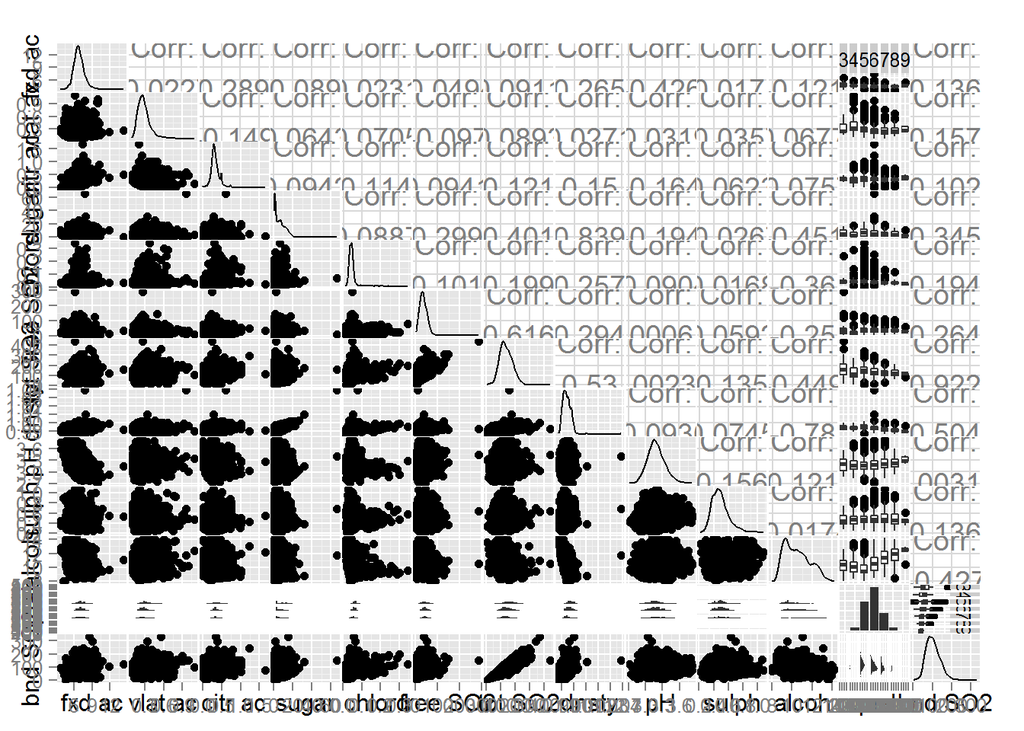

Let’s also run the ggcorr function for a clearer look at the correlations.

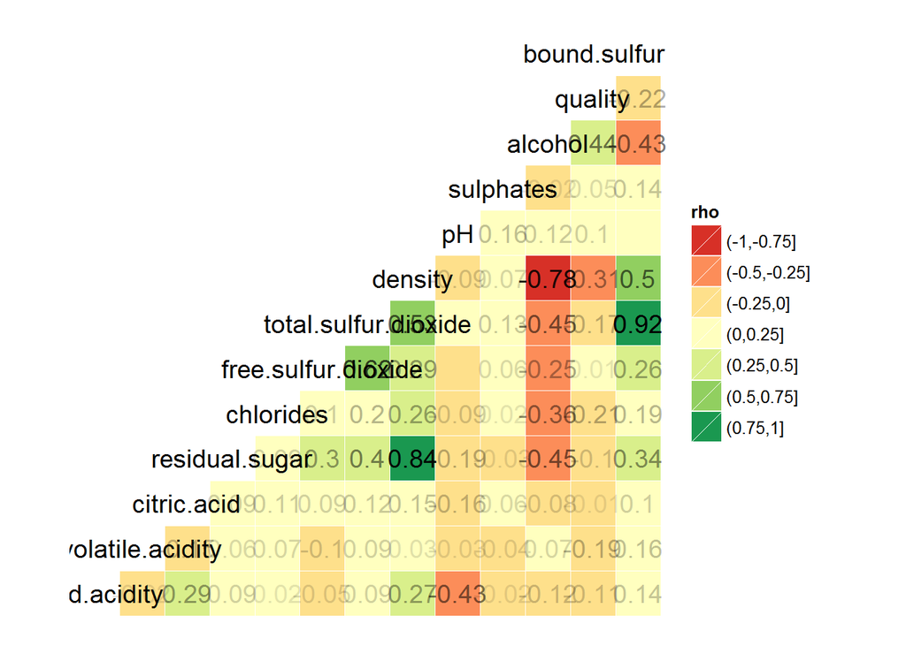

Now let’s take a closer look at the boxplots for *quality*, since they display too small in the ggpairs matrix output.

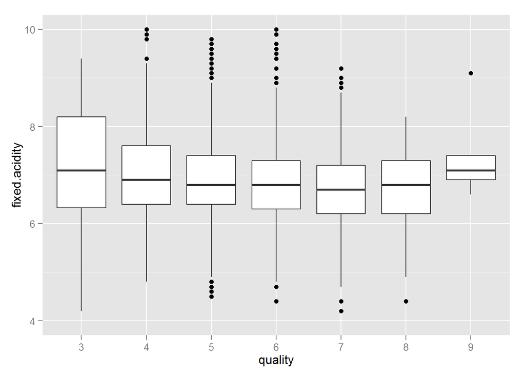

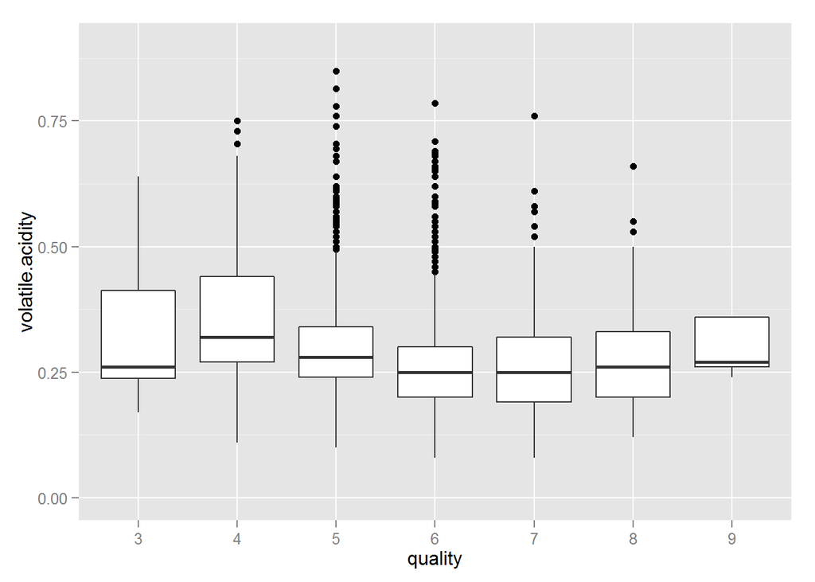

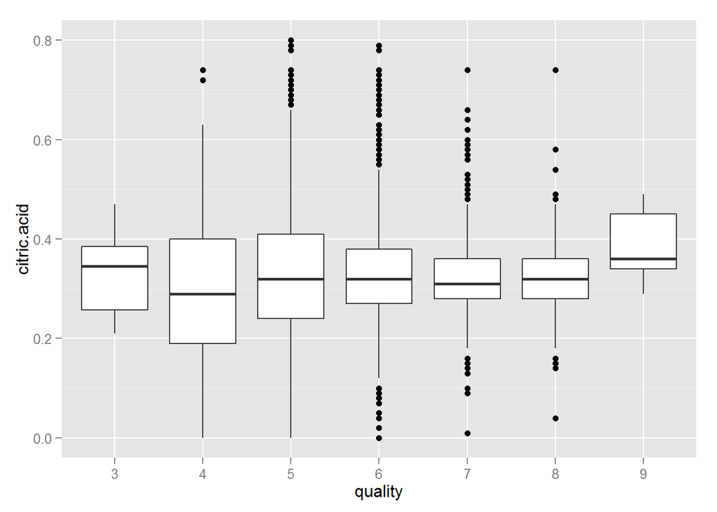

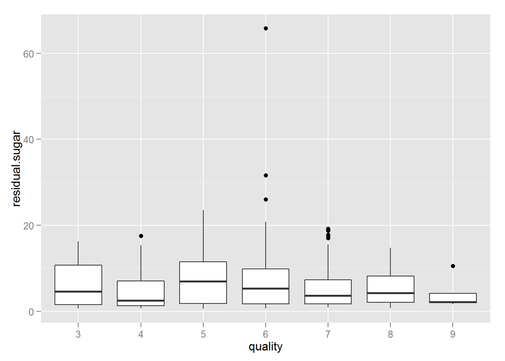

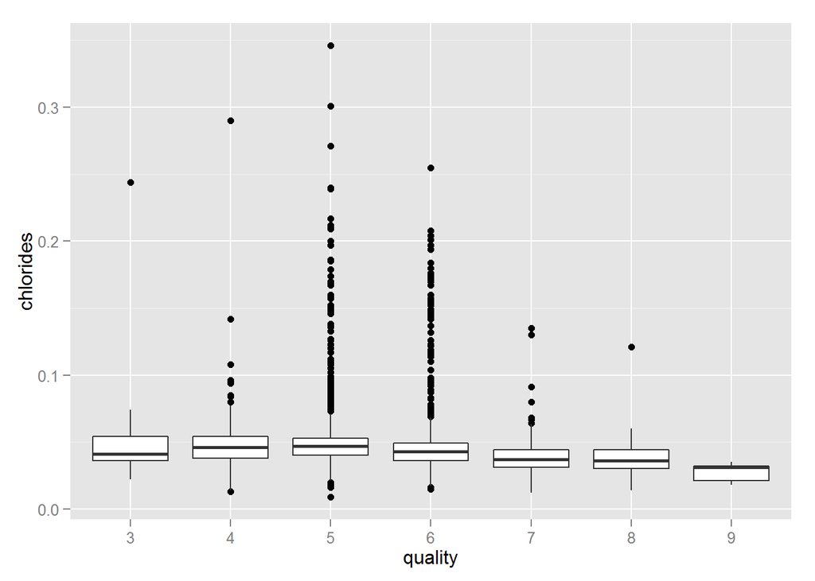

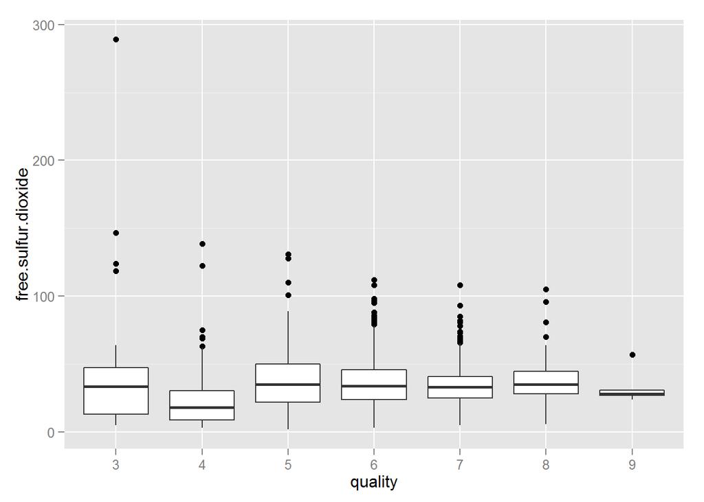

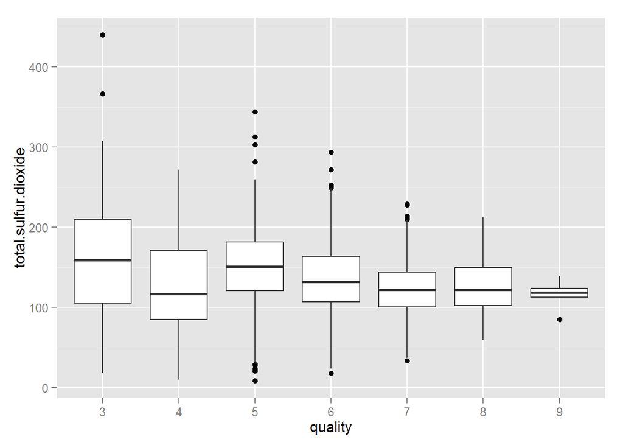

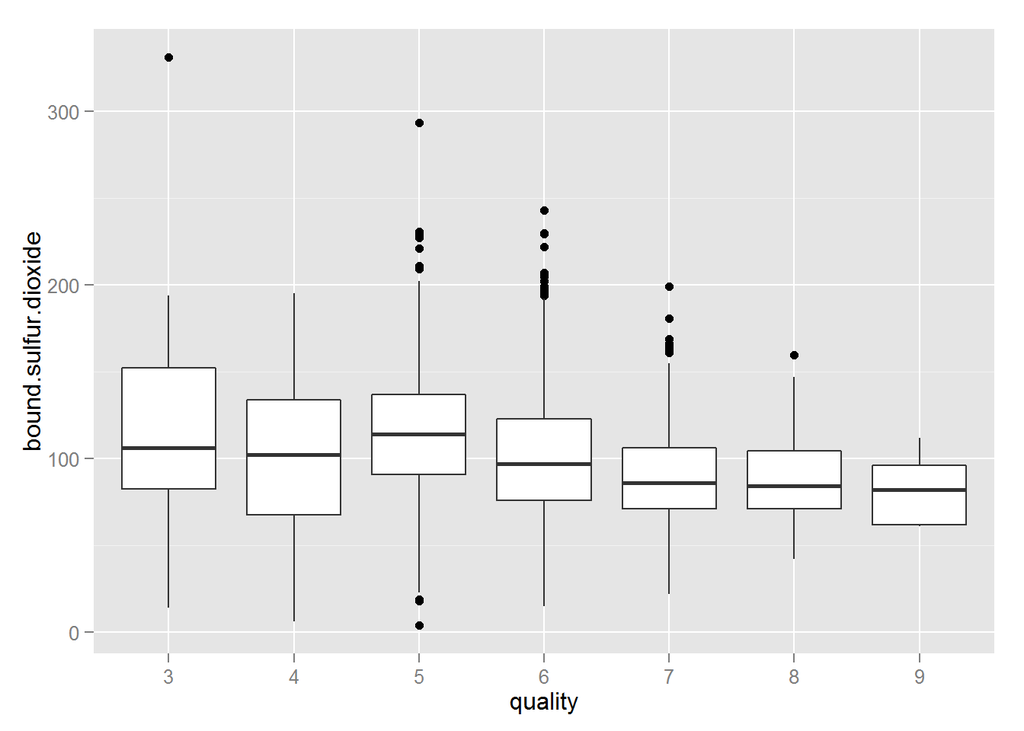

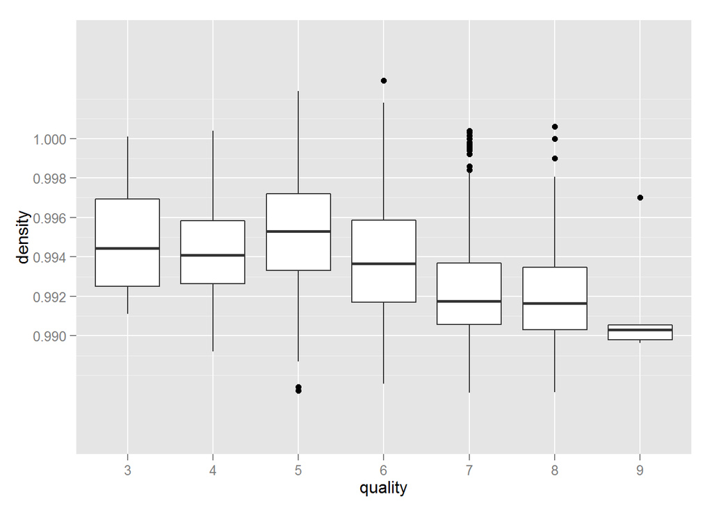

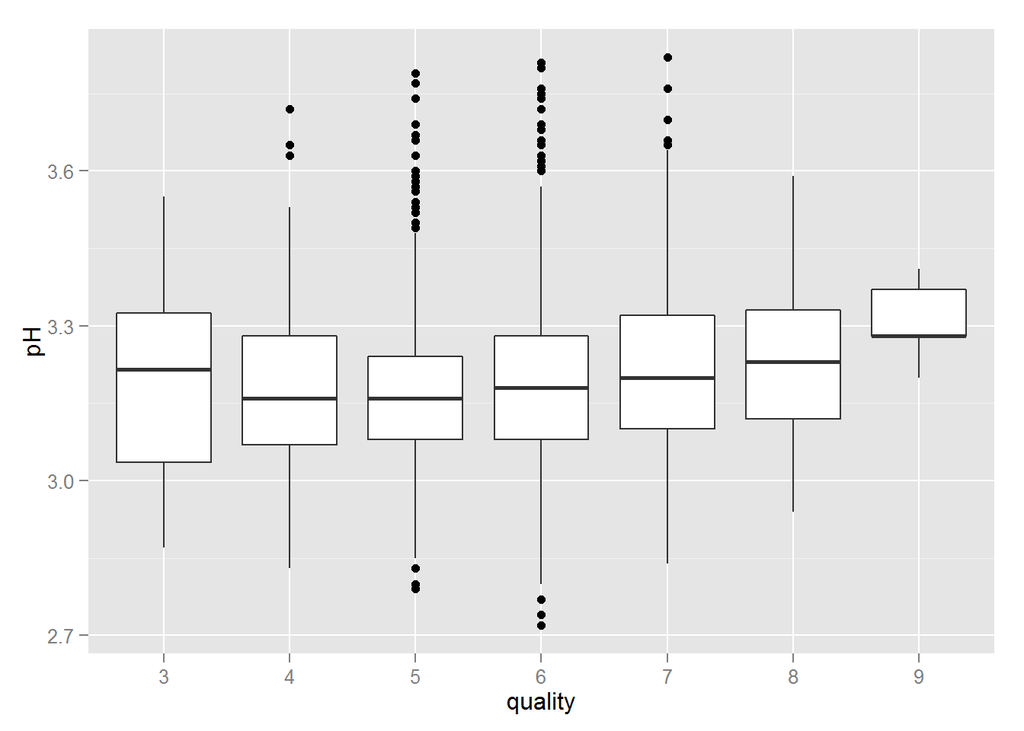

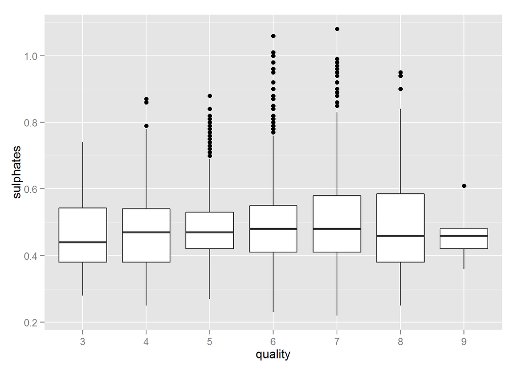

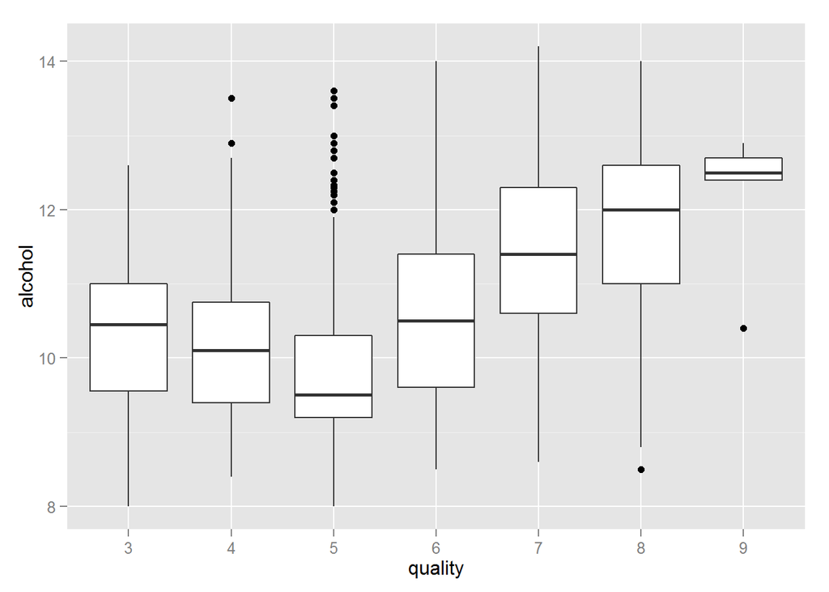

# Bivariate Analysis

### Talk about some of the relationships you observed in this part of the investigation. How did the feature(s) of interest vary with other features in the dataset?

A very interesting observation extracted from the above boxplots is that for several variables the interquartile range for wines of quality 9 is generally much narrower than those of lower quality wines. This is particularly true for variables *fixed.acidity*, *residual.sugar*, *total.sulfur.dioxide*, *density*, *sulphates* and *alcohol*.

Even considering there are just 5 wines of quality 9 in this dataset, such narrow value ranges could suggest these variables are some kind of “baseline” value for a wine to be considered of higher quality. Considering that these input variables are measured by physicochemical tests while the output variable *quality* is scored based on sensory evaluation, it is really interesting to note that experts seem to be able to rate the quality of a wine based on very specific characteristics only by using their senses.

### Did you observe any interesting relationships between the other features (not the main feature(s) of interest)?

By looking at the boxplots and the correlation matrix, an inverse/negative relationship can be observed between the quality of wine and *density*, which in turn has itself a stronger and more linear correlation with *alcohol* and *residual.sugar*, as can be seen in the second and third charts below.

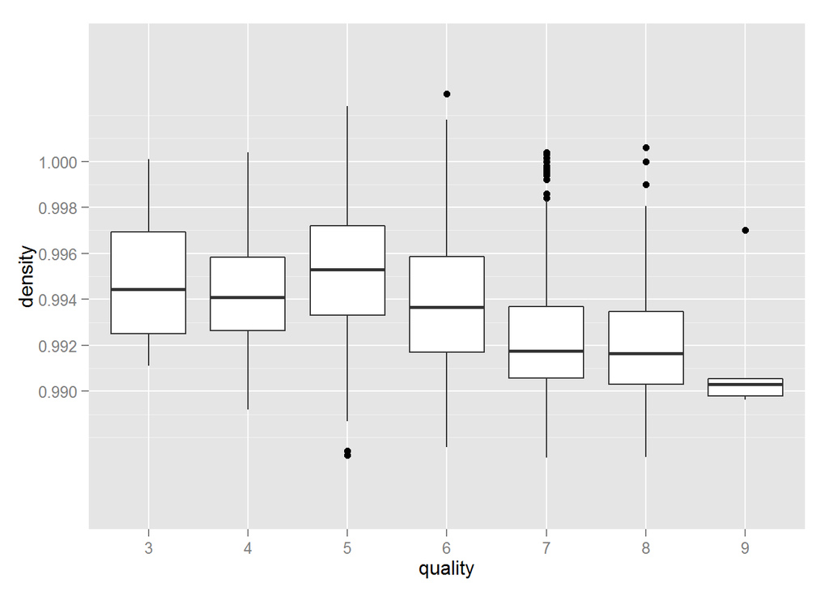

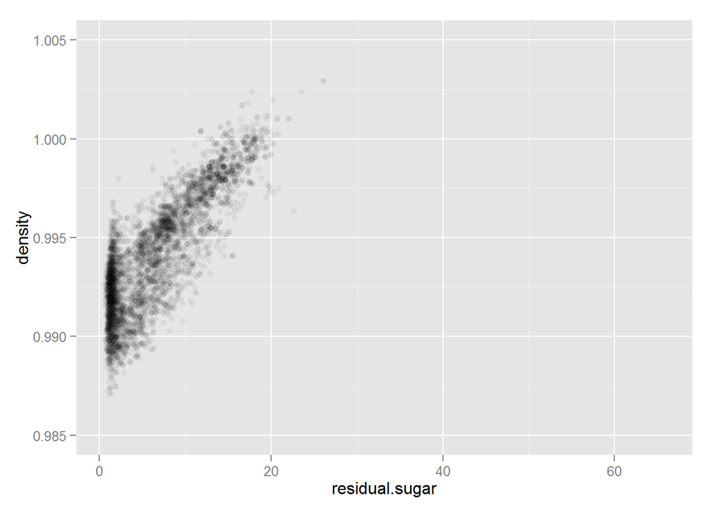

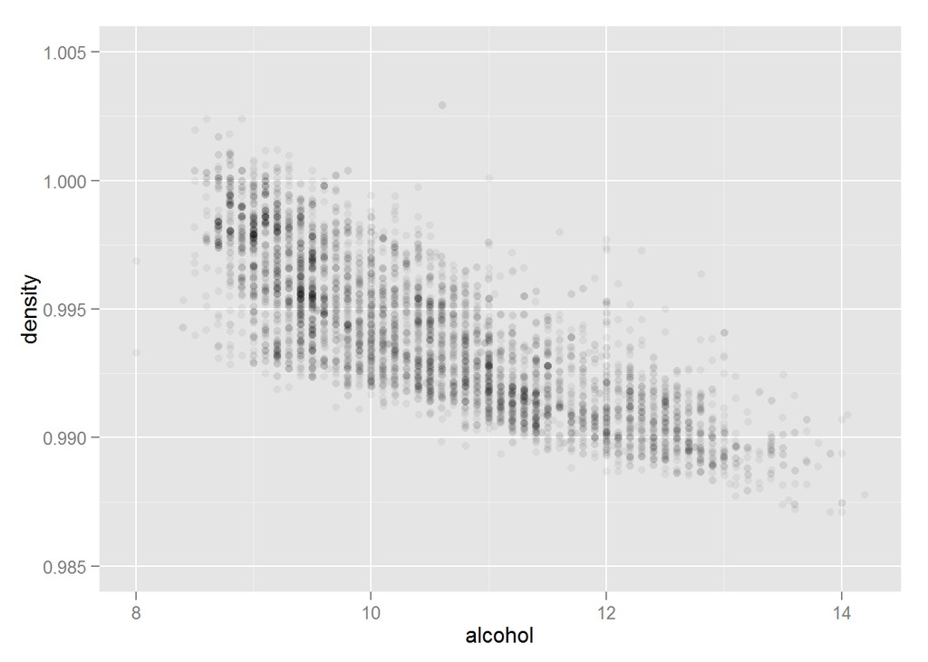